# Random Variables

Stat 241

## Discrete Random Variable

A random variable $X$ is a **discrete random variable** if the range of $X$ is finite or an infinite sequence of values. A discrete random variable can be characterized by a function called a **probability mass function (pmf)** which specifies the probability for each possible numerical value of the random variable.

$$p(x) = \operatorname{P}(X = x)$$
This function can be specified with a formula or in a table of probabilities. Given the pmf we can calculate the probability any event by adding the probabilities for all of the these values in the event.

**Example 1.** Toss a fair coin 5 times. Let $X$ = number of heads produced.

1. Create a probability table for $X$.
2. What is $\operatorname{P}(X \mbox{ is even})$?
3. What is $\operatorname{P}(X \ge 2)$?

### Binomial Random Variables

This example is an instance of an important kind of discrete random variabl called a **binomial random variable**. Binomial random variables arise in situations which have the following properties.

1. The random process consists of a **predetermined number of trials** (usually denoted $n$).
2. Each trial has **two outcomes** (generically called success and failure).
3. The **probability** of success **is the same for each trial** (often denoted $p$).
4. Each trial is **independent** of the others.
5. The random variable counts the **number of successes** in the $n$ trials.

Such a variable is dennoted by $X \sim {\sf Binom}(n, p)$.

There is a handy formula for the pmf of a ${\sf Binom}(n, p)$ random variable:

$$p(x) = \operatorname{P}(X = x) = \binom{n}{x} p^x (1-p)^{n-x}$$

where $\binom{n}{x} = \frac{n!}{x! (n-x)!}$. $\binom{n}{x}$ is read “n choose x” and counts the number of ways to pick a set of $x$ items from a collection of size $n$. This can be computed in R using the `choose()` function.

```r
choose(5, 2)
```

```
## [1] 10
```

```r
factorial(5) / (factorial(2) * factorial(3))
```

```
## [1] 10
```

**Example 2.** If we roll a fair die 10 times, what is the probability of getting 2 or more sixes?

**Example 3.** Two cards are dealt from an ordinary deck of playing cards. Let $X$ = number of aces dealt.

1. Create a probability table for $X$.
2. Is $X$ a binomial random variable? If so, what are $n$ and $p$? If not, why not?
3. What is $\operatorname{P}(X \ge 1)$?

**Example 4.** A fair coin is tossed until a head is produced. Let $X$ = number of tosses.

1. Create a probability table for $X$.
2. Can you give a formula for the pmf for $X$?
3. Can you show that the sum of all the probabilities is 1?
4. What is $\operatorname{P}(X \ge 4)$?
5. What is the probability it takes an even number of tosses to production first head? ($\operatorname{P}(X \mbox{ is even}$)

## Continuous Random Variables

A **continuous random variable** is a random variable whose range is an interval of real numbers.

**Examples**

- Randomly select an adult male: Let $X$ = (exact) height in inches
- Randomly select a washer produced by a particular machine. Let *X* = (exact) diameter in mm.
- Randomly select a battery and use it to power a device. Let $X$ = (exact) time until battery can no longer power device.

### Density histograms and density plots of data

Let’s consider the heights of the adult children in the `Galton` data set. Here is a **density histogram**.

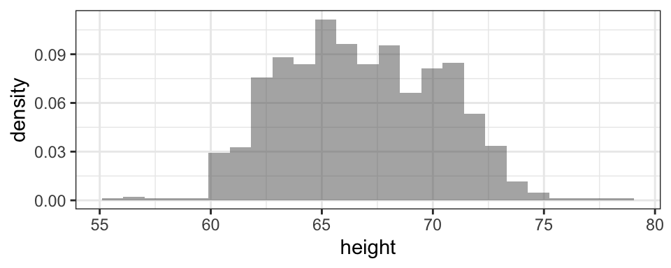

```r
gf_dhistogram( ~ height, data = Galton)
```

The density scale is chosen so that ___________________________________________.

Now let’s look at a density plot.

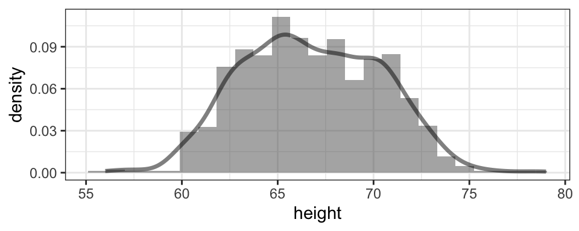

```r
gf_dhistogram( ~ height, data = Galton) %>%
gf_dens( ~ height, data = Galton, size = 1.2)
```

### Density Curves and Density Functions

A continuous random variable is described by a **probability density function (pdf)**. The plot of a pdf will look just like curve in a density plot.

We determine probabilities from a pdf but taking the area under the curve over the region corresponding to our event (ie, by integration).

$$\operatorname{P}( a \le X \le b) = \int_a^b f(x) \; dx$$

**Example 5.** Let $X$ be a number randomly chosen from the interval $[0, 2]$ in such a way that all numbers are equally likely. We call $[0, 2]$ the **support** of $X$ is [0,2].  
Since no value of $X$ is more likely to be selected than any other value, the density function $f(x)$ must be a constant on [0,2].

1. What is the constant value?
2. What is $\operatorname{P}(X = 1)$?
3. What is $\operatorname{P}(0 \le X \le 1)$?
4. Waht is $\operatorname{P}(1 \le X \le 3/2)$?
5. What is $\operatorname{P}(1 \le X \le 3)$?

A random variable $X$ whose pdf is constant (where it is non-zero) is said to have a **uniform distribution**. We will denote this as $X \sim {\sf Unif}(a, b)$, where $a$ and $b$ are the upper and lower limits of the support.

**Example 6.** Let $f(x) = x/2$ for $x \in (0,2)$ (and 0 elsewhere). We can write this as $f(x) = x/2 \cdot [\![x \in (0,2) ]\!]$ or $f(x) = x/2$ on $(0,2)$.

1. Verify that $f(x)$ is a probability density function.
2. Compute $\operatorname{P}(1 \le X \le 3/2)$.
3. Compute $\operatorname{P}(1 \le X \le 4)$.

### The Cumulative Distribution Function (cdf) for a continuous random variable

The **cdf** for $X$ is defined by

$$F(x) = \operatorname{P}(X \le x)$$

**Example 7.** Let $X$ have a uniform distribution on $[0,4]$.

1. pdf: $f(x) =$
2. cdf: $F(x) =$

**Example 8.** Let $X$ be the random variable whose pdf is $f(x) = x/2 \cdot [\![ x \in (0,2) ]\!]$. Find the cdf for $X$.

### Using the cdf to compute probabilities

If $F(x)$ is the cdf for the random variable $X$, then $\operatorname{P}(a \le X \le b) =$ ________________________

**Example 9.** Let $F(x)= x^2$ on $[0,1]$

1. What is $F(x)$ when $x < 0$?
2. What is $F(x)$ when $x > 0$?
3. What is $P(X \le 1/2)$?
4. What is $P(1/2 \le X \le 3/4)$?
5. What is $P(-2 \le X \le 1/2)$?
6. What is the pdf for $X$?

**Example 10.** Let $f(x) = e^{-x}$ on $(0,\infty)$ (and 0 elsewhere).

1. Show that $f$ is a pdf.
2. Let $X$ be the corresponding random variable. What is $\operatorname{P}(X > 2)$?
3. What is the cdf for $X$?
4. Use the cdf to find $\operatorname{P}(X < 1)$.

## More Practice

**1.** Parts coming off an assembly line have a 1% chance of being defective. If 3 parts are randomly chosen from this line and X is the number of defective parts.

1. Compute the probability function p(x) for X.
2. What is the probability that at least one of the three is defective?

**2.** Parts coming off an assembly line have a 1% chance of being defective. All of the parts coming off the line are inspected. Let $X$ be the number parts inspected up to and including the first defective part.

1. Is $X$ continuous or discrete?
2. What is the support of $X$?
3. Find the probability mass function $p(x)$ for $X$.
4. What is the probability that the first defective part is the 100th part?

**3.** A biased coin has a 40% chance of producing a head. If it is tossed 10 times,

1. What is the probability of getting exactly 3 heads?
2. What is the probability of getting 3 or more heads. (This can be calculated in two different ways. The easier way uses the complement rule.)

**4.** a. Find the value of $C$ for which the function $f(x) = C x^2 \cdot [\![ x \in (0,2) [\!]$ is a pdf.

2. Use the pdf to find $\operatorname{P}(0 \le X \le 1)$ and $\operatorname{P}(1 \le X \le 5)$.
3. Use the pdf to compute the cumulative distribution function $F(x)$.

**5.** a. Find the value of $C$ for which the function $f(x) = \frac{C}{x^2} \cdot [\![ x \ge 1 ]\!]$ is a pdf.

2. What is $\operatorname{P}(X \le 2)$?
3. What is $\operatorname{P}(X > 3)$?
4. Find the cumulative distribution function $F(x)$.
5. Use the cumulative distribution function to find $\operatorname{P}(2 \le X \le 5)$.